# Value in Voting

Karun Rajesh, Han Truong, Davy Deng

## Introduction and Overview

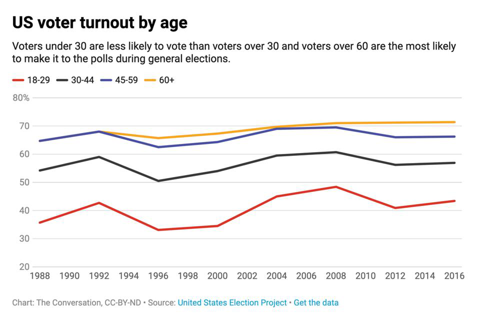

Voter Turnout by Age

Without this knowledge of value, people will not understand the impact they can have and continue to be unseen in elections. To increase voter turnout, it is imperative that the value of one’s vote becomes clear at every level of election around them. For instance, the 2020 election has been one of the most heavily funded elections with the most voter turnout in U.S. history. The record number of civil engagements highlighted the importance of this election. We have seen many different organizations like the NFL, NBA, Facebook, and others continuously push voting ad-campaigns like never before. It immediately made us think about the value of our singular votes and how much change we can affect with just this one action. We also wanted to provide an alternative view to the case of voting, besides the worn out “civic duty” argument, to peers around us who did not see reason in voting.

However, just how much is your vote worth? How much does a vote actually matter in terms of its economic impact? These questions could be critical in future campaign in promoting voting by directly demonstrating in a quantitative fashion how much impact each vote makes.

In order to begin answering these questions, we obtained a detailed breakdown of data on voter turnout, how much money each administration has spent on relevant sectors such as education, agriculture, military dense etc. and the possibility of a single vote overturning election results by state from past US presidential elections. We then can calculate the monetary value of each vote for particular sectors of interests. Further we hope to use these datasets to draw inferences for the values in a single vote in 2024 election.

## Related Work

While civil engagement has been a topic of interest for an extended period of time, when searching literature bases, we found that most of the studies on values in voting are related to communal moral values and political social values, instead of our focus on physical monetary values.

The value of a singular vote is often discussed in many commentaries and literature. For example, the article titled “The Importance of Voting” (https://www.castleton.edu/news-media/article/the-importance-of-voting/) discussed how many political scientists and civic educators express the idea that voting is important without explaining why that is the case. It also discussed this misconception that many Americans have about their votes appearing unimportant and unlikely to make a difference. It presents the striking statistics that for 2016 presidential election, the entire outcome hinged on approximately 78,000 votes, or less than 0.06% of the total votes cast. More so, in 2017, the 94th District of the Virginia House of Delegates, wherein 11,608 ballots were cast, resulted in a tie, and the winner was chosen by randomly drawing a name from a hat. These tight races all highlight the importance of even singular votes and similar examples vastly exceed just the two mentioned above.

On the other hand, research in voter turnout has shown that the U.S. trails consistently most developed countries. According to Pew Research (https://www.pewresearch.org/fact-tank/2020/11/03/in-past-elections-u-s-trailed-most-developed-countries-in-voter-turnout/), in 2016, the U.S. had a 55.7% VAP turnout which puts the U.S. behind most of its peers in the Organization for Economic Cooperation and Development, most of whose members are highly developed democratic states. Additionally, turnout rate for people of color was also a concerned with a significant decline in the 2016 election, according to Pew Research (https://www.pewresearch.org/fact-tank/2017/05/12/black-voter-turnout-fell-in-2016-even-as-a-record-number-of-americans-cast-ballots/). These studies suggest that conveying the monetary values of civic engagement, and targeted support for people of color and underrepresented minority are important to facilitate higher voter turnout and could be highly beneficial to the democratic process.

## Initial Questions

Our dataset includes historical data on how much money each administration spent or proposed to spend on different sectors, historical voter turnout by states, and the winning margin in historical presidential election by states. As a voter who cares about a particular sector, how much money is my singular vote corresponding to the spending in that sector, given the chances of my vote flipping the result of a presidential election based on the state that I live in?

Furthermore, is there a relationship between the voter turnout in a state and the margin of winning in a state in past presidential elections?

Lastly, using the designation of “swing state” defined by the narrow winning margins, can we predict what states will most likely to be a key competitive swing state in the 2024 presidential election using the historical data on the margin of the winning party? Is this competitiveness classification correlated with voter turnout in each state?

## Data Sources:

In this project, we use three main data sources, supplemented by other various datasets that have been web scraped. These sources allowed us to quantify the value of a single vote over the past 40 years of presidential elections.

#### MIT Election Lab

The MIT Election Lab is an online repository that stores past years (up to 1976) of election data at various levels (senate, presidential, etc.) These datasets are continuously updated each year, with new elections. Data in this repository is thoroughly cleaned, such that users can perform their own analysis directly after downloading. This dataset was used to obtain the voter turnout for each state at both the presidential and senate level (1976 - 2016). It lists not only the winner’s vote total for each state, but also other candidates’ vote totals as well. From this dataset, we were able to derive voter turnout by state, margins of victory by state, and flipping of states between elections from 1976 to 2016.

```r
presidential <- read.csv("Data/1976-2016-president.csv")
senate <- read.csv("Data/1976-2018-senate.csv")

head(presidential)
```

|  | year | state | state_po | state_fips | state_cen | state_ic | office | candidate | party | writein | candidatevotes | totalvotes | version | notes |
| --- | --- | --- | --- | --- | --- | --- | --- | --- | --- | --- | --- | --- | --- | --- |
| 1 | 1976 | Alabama | AL | 1 | 63 | 41 | US President | Carter, Jimmy | democrat | FALSE | 659170 | 1182850 | 20171015 | NA |
| 2 | 1976 | Alabama | AL | 1 | 63 | 41 | US President | Ford, Gerald | republican | FALSE | 504070 | 1182850 | 20171015 | NA |
| 3 | 1976 | Alabama | AL | 1 | 63 | 41 | US President | Maddox, Lester | american independent party | FALSE | 9198 | 1182850 | 20171015 | NA |
| 4 | 1976 | Alabama | AL | 1 | 63 | 41 | US President | Bubar, Benjamin ""Ben"" | prohibition | FALSE | 6669 | 1182850 | 20171015 | NA |
| 5 | 1976 | Alabama | AL | 1 | 63 | 41 | US President | Hall, Gus | communist party use | FALSE | 1954 | 1182850 | 20171015 | NA |
| 6 | 1976 | Alabama | AL | 1 | 63 | 41 | US President | Macbride, Roger | libertarian | FALSE | 1481 | 1182850 | 20171015 | NA |

We then took the presidential and senate dataset and subset it into various other datasets. The dataframe below holds the voter turnout over time, aggregated by state and year.

```r
#Voter Turnout Over Time

# Aggregate Senate by state
senate_turnout <- senate %>%
  group_by(year, state) %>%
  filter(row_number()==1) %>%
  dplyr::select(year, state, totalvotes)

# Aggregate Presidential Election by state
presidential_turnout <- presidential %>%
  group_by(year, state) %>%
  filter(row_number()==1) %>%
  dplyr::select(year, state, totalvotes)
```

The dataframe below holds the margin of victory for each presidential race, aggregated by state and year.

```r
#Margins of Victory

# Aggregate Presidential Election by state
margin_pres <- presidential %>%
  group_by(year,state) %>%
  arrange(desc(candidatevotes), .by_group = TRUE) %>%
  filter(row_number() %in% c(1,2)) %>% # Get top 2 candidates
  dplyr::select(year, state, candidate, candidatevotes, totalvotes, party) %>%
  summarize(margin = mean((candidatevotes[1]-candidatevotes[2])/totalvotes), party = party[1]) #Take difference between candidates and divide by total votes

margin_sen <- senate %>%
  group_by(year,state) %>%
  arrange(desc(candidatevotes), .by_group = TRUE) %>%
  filter(row_number() %in% c(1,2)) %>%
  dplyr::select(year, state, candidate, candidatevotes, totalvotes, party) %>%
  summarize(margin = mean((candidatevotes[1]-candidatevotes[2])/totalvotes), party = party[1])
```

The dataframe below holds the party that won for each presidential race, aggregated by state and year.

```r
# Switching Parties

# Aggregate Presidential Election by state
parties_pres <- presidential %>%
  group_by(year,state) %>%
  arrange(desc(candidatevotes), .by_group = TRUE) %>%
  filter(row_number() == 1) %>% # Get the winner for the given state
  dplyr::select(year, state, candidate, party)
parties_sen <- senate %>%
  group_by(year,state) %>%
  arrange(desc(candidatevotes), .by_group = TRUE) %>%
  filter(row_number() == 1) %>%
  dplyr::select(year, state, candidate, party)
```

We also used an analysis dataset published from this repository. This dataset consisted of the voter demographics in each county of the United States for the 2012 and 2016 presidential elections. It included voting breakdowns by race, gender, age, level of education, level of employment, and environment. We used this to understand more about the voting population, as well as, predict the value of a vote.

```r
context <- read.csv("Data/election-context-2018.csv")
head(context)
```

|  | state | county | fips | trump16 | clinton16 | otherpres16 | romney12 | obama12 | otherpres12 | demsen16 | repsen16 | othersen16 | demhouse16 | rephouse16 | otherhouse16 | demgov16 | repgov16 | othergov16 | repgov14 | demgov14 | othergov14 | total_population | cvap | white_pct | black_pct | hispanic_pct | nonwhite_pct | foreignborn_pct | female_pct | … |
| --- | --- | --- | --- | --- | --- | --- | --- | --- | --- | --- | --- | --- | --- | --- | --- | --- | --- | --- | --- | --- | --- | --- | --- | --- | --- | --- | --- | --- | --- | --- |
| 1 | Alabama | Autauga | 1001 | 18172 | 5936 | 865 | 17379 | 6363 | 190 | 6331 | 18220 | 62 | 7544 | 14315 | 2258 | NA | NA | NA | 9427 | 3638 | 0 | 55049 | 40690 | 75.68348 | 18.370906 | 2.5722538 | 24.31652 | 1.838362 | 51.17622 | … |
| 2 | Alabama | Baldwin | 1003 | 72883 | 18458 | 3874 | 66016 | 18424 | 898 | 19145 | 74021 | 248 | 0 | 76995 | 1991 | NA | NA | NA | 37650 | 8416 | 0 | 199510 | 151770 | 83.17879 | 9.225603 | 4.3666984 | 16.82121 | 3.269510 | 51.19493 | … |
| 3 | Alabama | Barbour | 1005 | 5454 | 4871 | 144 | 5550 | 5912 | 47 | 4777 | 5436 | 16 | 5297 | 4286 | 463 | NA | NA | NA | 3111 | 3651 | 0 | 26614 | 20375 | 45.88562 | 47.888329 | 4.3097618 | 54.11438 | 2.859397 | 46.49808 | … |
| 4 | Alabama | Bibb | 1007 | 6738 | 1874 | 207 | 6132 | 2202 | 86 | 2082 | 6612 | 17 | 1971 | 6670 | 15 | NA | NA | NA | 3525 | 1368 | 0 | 22572 | 17590 | 74.76520 | 21.212121 | 2.2239943 | 25.23480 | 1.351232 | 46.46465 | … |
| 5 | Alabama | Blount | 1009 | 22859 | 2156 | 573 | 20757 | 2970 | 279 | 2980 | 22169 | 48 | 2390 | 22367 | 47 | NA | NA | NA | 12074 | 2178 | 0 | 57704 | 42430 | 87.65770 | 1.557951 | 8.7272979 | 12.34230 | 4.271801 | 50.48523 | … |
| 6 | Alabama | Bullock | 1011 | 1140 | 3530 | 40 | 1251 | 4061 | 10 | 3364 | 1167 | 6 | 3517 | 889 | 80 | NA | NA | NA | 747 | 2440 | 0 | 10552 | 8195 | 21.68309 | 75.502274 | 0.1231994 | 78.31691 | 1.516300 | 45.80174 | … |

We then aggregated this demographic data by state, as it was currently separated by county.

```r
# Aggregate Demographics by state
context_state<- context %>%
  group_by(state) %>%
  dplyr::select(-county) %>% # Get rid of county variable
  summarise_each(funs(mean)) # Get mean within each county
```

#### White House Office of Management and Budget

The White House’s Office of Management and Budget website contains historical tables that detail spending over several different categories (discretionary, deficits, agency, etc.) From this site, we were able to download the discretionary spending estimates over each year, starting from 1976, to an estimated amount in 2025. These estimates were split by agencies (Department of Defense, Department of Education, Department of Transportation, etc.) This was downloaded as a csv file, which was then cleaned in R.

We aggregated this data over each president’s term to get the total discretionary spending per term. This was then used to find the monetary value of one person’s vote in a given state for the given election year.

```r
# Contains the mandatory federal spending per year per agency
budg_all <- read.csv("Data/budget_amount.csv")
budg_all <- data.frame(lapply(budg_all, as.character), stringsAsFactors=FALSE) # Convert factor columns to character
colnames(budg_all) = budg_all[2,]
rownames(budg_all) = budg_all[,1]
budg_all = budg_all[-c(1,2,33,34),-1]
cols <- colnames(budg_all)
rows <- rownames(budg_all)
budg = as.data.frame(lapply(budg_all, function(x) as.numeric(gsub(",","",x)))) # Take out comma in numerical values
colnames(budg) <- cols
rownames(budg) <- rows
budg <- budg[,-c(1,2)]
budg_admin <- as.data.frame(sapply(seq(1,dim(budg)[2]-1,by=4),function(i) rowSums(budg[,i:(i+3)], na.rm=TRUE))) # Aggregate each of the president's discretionary budget in their four years of presidency
colnames(budg_admin) <- c(as.numeric(colnames(budg[,seq(1,dim(budg)[2]-5,by=4)])) - 1, 2020)

head(budg_admin)
```

|  | 1976 | 1980 | 1984 | 1988 | 1992 | 1996 | 2000 | 2004 | 2008 | 2012 | 2016 | 2020 |
| --- | --- | --- | --- | --- | --- | --- | --- | --- | --- | --- | --- | --- |
| Legislative Branch | 4543 | 5868 | 6654 | 8382 | 9168 | 9723 | 13293 | 15521 | 18341 | 17270 | 19468 | 22607 |
| Judicial Branch | 1996 | 3072 | 4661 | 7051 | 10339 | 13265 | 17878 | 21876 | 25519 | 26170 | 28742 | 31220 |
| Department of Agriculture | 23852 | 30701 | 35513 | 48059 | 62847 | 64485 | 83238 | 96390 | 107095 | 98272 | 114046 | 98933 |
| Department of Commerce | 14428 | 7952 | 9093 | 12179 | 14873 | 22036 | 21955 | 27459 | 44264 | 33808 | 49474 | 31291 |
| Department of Defense--Military Programs | 488232 | 886277 | 1133483 | 1191238 | 1019100 | 1075773 | 1566666 | 2280331 | 2689392 | 2299657 | 2677099 | 2916912 |
| Department of Education | 43138 | 45409 | 59218 | 79929 | 94924 | 114517 | 198370 | 230678 | 355272 | 268265 | 283110 | 266239 |

#### United States Election Project

The United States Election Project is an information source that houses election data for each state over the past 50 years of elections. This source was mainly used to obtain the voter turnout as a percentage of the total eligible voters. As can be seen, we do not have data from the 1976 and 2016 election. This dataset was combined with two other sources that were web scraped to obtain the full voter turnout per state from the 1976 to 2016 presidential election.

```r
check <- read.csv("Data/Turnout.csv")
check <- check %>%
  filter(X %in% seq(1976, 2016, by = 4)) %>%
  filter(State != "United States") %>% # Remove United States from the dataset
  select(X, State, X.4)
colnames(check) <- c("Year", "State", "Turnout")
check$Year <- as.numeric(as.character(check$Year))
total_turnout <- check
total_turnout$Turnout <- as.numeric(gsub("%","",total_turnout$Turnout)) # Remove the % in turnout
head(total_turnout)
```

|  | Year | State | Turnout |
| --- | --- | --- | --- |
| 1 | 2012 | Alabama | 56.0 |
| 2 | 2012 | Alaska | 55.3 |
| 3 | 2012 | Arizona | 46.5 |
| 4 | 2012 | Arkansas | 47.7 |
| 5 | 2012 | California | 45.1 |
| 6 | 2012 | Colorado | 64.5 |

#### Andrew Gelman

Andrew Gelman is a professor of statistics and political science at Columbia University. He was one of the first people to publish studies that utilized statistical models to quantify the value of a vote. His work in the field motivated much of this work, and also served as a key data source. He published an article on Slate (https://slate.com/news-and-politics/2016/11/here-are-the-chances-your-vote-matters.html) that listed the probability of a single vote being decisive in the 2012 election.

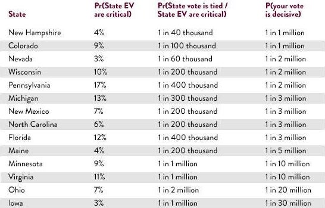

Adapted from Gelman’s Slate Article

These were separated by states, with battleground states having higher values, Wisconsin with a 1 in 2 million chance, and dominant states having lower values, Oklahoma with a 1 in 30 billion chance. We used the probability of influencing an election, along with the discretionary budget data, to find the monetary value of a vote based on state and year. It should be noted that we do not replicate Gelman’s statistical models over each election year and utilize just one election year for our analysis.

```r
#Adapted from: https://slate.com/news-and-politics/2016/11/here-are-the-chances-your-vote-matters.html
# The table was an image, so we had to manually input all values
# We obtained all state abbreviations with state.abb

influence = data.frame(state = c(state.abb),
                       chance = c(1/7e9,1/100e6,1/40e6, 1/3e9,
                                 1/7e9,1/1e6, 1/40e6, 1/300e6,
                                 1/3e6, 1/60e6, 1/1e9, 1/10e9,
                                 1/1e9, 1/3e9, 1/30e6, 1/1e9,
                                 1/8e9, 1/5e9, 1/5e6, 1/10e9,
                                 1/4e9, 1/3e6, 1/10e6, 1/1e9,
                                 1/1e9, 1/2e9, 1/4e9, 1/2e6,
                                 1/1e6, 1/400e6, 1/3e6, 1/3e9,
                                 1/3e6, 1/4e9, 1/20e6, 1/30e9,
                                 1/40e6, 1/2e6, 1/30e6, 1/100e6,
                                 1/3e9, 1/3e9, 1/1e9, 1/2e9,
                                 1/10e9, 1/10e6, 1/200e6, 1/9e9,
                                 1/2e6, 1/30e9))
```

#### Web Scraping

We web scraped several other datasets to fill in gaps found throughout the process. One of these was the voter turnout from 2016. This was obtained by scraping a table from sos.nh.gov that contained voter turnout in the year 2016. Various other datasets that showed differences in administration’s proposed budgets were also web scraped from https://www.thebalance.com/ . This site contains the breakdown of discretionary spending per year, and contains tables comparing President Trump to President Obama’s (2012) proposed budgets. We also scraped data from govinfo.gov that contained data comparing President Bush’s and President Obama’s (2008) proposed budget. We realized that it would not be efficient to download each year as a separate web scraped table, so we replaced these with the White House OMB data.

```r
# Web Scraping, NOT USED SINCE OMB HAS SAME INFORMATION

# Clean table obtained from web scraping
clean_table <- function(df){
  rownames(df) <- df[,1]
  df[,1] <- NULL
  colnames(df) <- df[1,]
  df <- df[-1,]
}

# Compares the Obama and Trump Discretionary Budget Proposals
turl <- "https://www.thebalance.com/how-trump-amended-obama-budget-4128986"
h   <- read_html(turl)
try <- h %>% html_nodes("table") %>% .[1]
budget_comp <- try %>% html_table %>% .[[1]]

budget_comp <- clean_table(budget_comp)

head(budget_comp)
```

|  | Obama Budget | Trump Budget | Enacted | Spent |
| --- | --- | --- | --- | --- |
| Defense Dept. | $523.9 | $546.6 | $516.1 | $523.2 |
| Education | $69.4 | $63.6 | $68.0 | $66.9 |
| Energy | $30.2 | $27.7 | $37.8 | $30.2 |
| NNSA | $12.9 | $12.5 | $12.9 | $12.8 |
| Health | $77.9 | $72.4 | $73.5 | $87.1 |
| Homeland | $40.6 | $44.1 | $42.4 | $42.4 |

[output not shown]

In order to find the full voter turnout from 1976 to 2016 presidential elections, we had to web scrape the voter turnout for the 2016 election. We then manually input the data for the 1976 presidential election voter turnout.

```r
# Get the 2016 table from the pdf
location <- 'https://sos.nh.gov/media/ni0j3zb5/1976-2016-presidental-election-highest-office-divided-by-vap.pdf'
out <- extract_tables(location)
df <- out[[2]]
final <- as.data.frame(df)
final <- final[,-c(1,4,7,10,13,16)]
final <- data.frame(lapply(final, as.character), stringsAsFactors=FALSE) # Conver factor to character
colnames(final) <- final[1,]
final <- final[-1,]

final <- final[,c(11,12)]
final <- final %>%
  filter(`2016` != "United States") # Remove United States from the dataset
final$X <- 2016
final <- final[,c(3,1,2)]
colnames(final) <- c("Year", "State", "Turnout")
final$Year <- as.numeric(final$Year)

write.csv(final,"Data/2016_Turnout.csv",row.names=F) #Write csv to the Data folder

# Manually put in the 1976 voter turnout, since could not parse the file
old_turnout <- data.frame(State = c("Minnesota", "Utah", "North Dakota", "Wisconsin", "South Dakota", "Maine", "Montana", "Iowa", "Conneticut", "Massachusetts", "Oregon", "Idaho", "Indiana", "Washington", "Rhode Island", "Illinois", "Colorado","Kansas", "Michigan","Wyoming","New Jersey","Missouri", "New Hampshire","Delaware","West Virginia", "Nebraska","Vermont","Ohio","Oklahoma", "Pennsylvania", "New Mexico","Arkansas","New York", "California","Maryland","Florida","Louisiansa", "Tennessee","Alaska","Mississippi","Kentucky", "Virginia","Hawaii","Texas","Alabama","Arizona","Nevada","North Carolina","Georgia","South Carolina", "District of Columbia"), Turnout = c(71.5, 68.4, 67.2, 66.5, 64.1, 63.6, 63.3,
                       63.1, 62.7, 61.6, 61.3, 60.6, 60.1, 59.8,
                       59.6, 59.4, 58.8, 58.8, 58.8, 58.5, 57.7,
                       57.3, 57.2, 57.2, 57.1, 56.2, 55.7, 55.1,
                       54.8, 54.1, 53.4, 51.1, 50.6, 50.4, 49.3,
                       49.1, 48.7, 48.6, 48.0, 48.0, 47.9, 46.9, 46.6,
                       46.3, 46.3, 46.1, 44.1, 42.9, 42.0, 40.2,
                       32.2))
old_turnout$Year <- 1976
old_turnout <- old_turnout[,c(3,1,2)]

write.csv(old_turnout,"Data/1976_Turnout.csv",row.names=F)

total_turnout <- rbind(total_turnout, old_turnout) #Append the dataframes together


# how we are reading turnout in shiny app,
turnout <- read.csv("Data/Turnout.csv") %>%
  filter(X %in% seq(1976, 2016, by = 4)) %>%
  select(X, State, X.4) %>%
  rename(year=X,state=State, turnout=X.4)
turnout_1976 <- read.csv("Data/1976_Turnout.csv")
turnout_2016 <- read.csv("Data/2016_Turnout.csv") %>% mutate(State=recode(State,!!!c("Dist. of Columbia"="District of Columbia")))

#Append the dataframes fully
pr_turnout <- turnout_1976 %>%
  rename(year=Year,state=State,turnout=Turnout) %>% rbind(turnout) %>%
  rbind(turnout_2016 %>% rename(year=Year,state=State,turnout=Turnout)) %>%
  mutate(year = as.numeric(as.character(year)),turnout=as.numeric(str_replace(turnout,"%",""))) %>%
  filter(state !='United States')

head(pr_turnout)
```

|  | year | state | turnout |
| --- | --- | --- | --- |
| 1 | 1976 | Minnesota | 71.5 |
| 2 | 1976 | Utah | 68.4 |
| 3 | 1976 | North Dakota | 67.2 |
| 4 | 1976 | Wisconsin | 66.5 |
| 5 | 1976 | South Dakota | 64.1 |
| 6 | 1976 | Maine | 63.6 |

## Exploratory Analysis

We broke down our exploratory analysis into five main portions:

- Demographics
- Voting Trends Over Time
  - Voter Turnout
  - Voting Margin of Victory
  - Election Result by State
- Chance of Influencing a Single Election
- Discretionary Budget Breakdown
- Value of a Vote

#### Demographics

Here we show the demographics for the 2016 election:

```r
# Demographics, 2016 Election
demo <- context_state[,-c(2:22)]
demo <- demo %>%
  filter(!state %in% c("Missouri", "Virginia", "South Dakota"))
head(demo)
```

| state | white_pct | black_pct | hispanic_pct | nonwhite_pct | foreignborn_pct | female_pct | age29andunder_pct | age65andolder_pct | median_hh_inc | clf_unemploy_pct | lesshs_pct | lesscollege_pct | lesshs_whites_pct | lesscollege_whites_pct | rural_pct | ruralurban_cc |
| --- | --- | --- | --- | --- | --- | --- | --- | --- | --- | --- | --- | --- | --- | --- | --- | --- |
| Alabama | 65.40143 | 28.623775 | 3.218275 | 34.59857 | 2.315996 | 51.27466 | 37.86408 | 16.93007 | 38834.93 | 10.103144 | 19.149822 | 83.08087 | 15.425409 | 80.15360 | 67.08605 | 4.641791 |
| Arizona | 51.21812 | 1.783460 | 30.598920 | 48.78188 | 10.399852 | 49.55215 | 39.68783 | 18.95175 | 44166.53 | 11.002507 | 16.793000 | 80.58944 | 8.525577 | 73.62492 | 34.10852 | 3.800000 |
| Arkansas | 75.92603 | 16.168268 | 4.950620 | 24.07397 | 2.877551 | 50.58349 | 37.33350 | 18.25900 | 37503.72 | 8.190428 | 17.518907 | 84.49962 | 15.043415 | 83.03103 | 64.87069 | 5.640000 |
| California | 55.25200 | 2.958796 | 29.761858 | 44.74800 | 17.019202 | 49.31306 | 38.68123 | 15.96278 | 58091.24 | 9.489258 | 16.420405 | 73.98856 | 6.946791 | 67.97394 | 28.69574 | 3.344828 |
| Colorado | 74.85842 | 1.531686 | 19.988524 | 25.14158 | 6.429235 | 48.47361 | 35.15412 | 17.29424 | 52243.59 | 6.585372 | 9.683520 | 69.55589 | 5.257206 | 65.60958 | 58.67793 | 5.796875 |
| Connecticut | 76.54175 | 6.413566 | 11.136371 | 23.45825 | 10.473621 | 50.82257 | 36.92283 | 15.78772 | 72395.00 | 7.410152 | 9.045764 | 64.05065 | 6.495212 | 61.21389 | 24.17482 | 1.875000 |

#### Voting Trends Over Time

We first wanted to explore trends in voter turnout over time. The plots below show the overall voter turnout from 1976 to 2016, as well as state level voter turnout. In our shiny app, we allow the user to select up to six states to display the voter turnout.

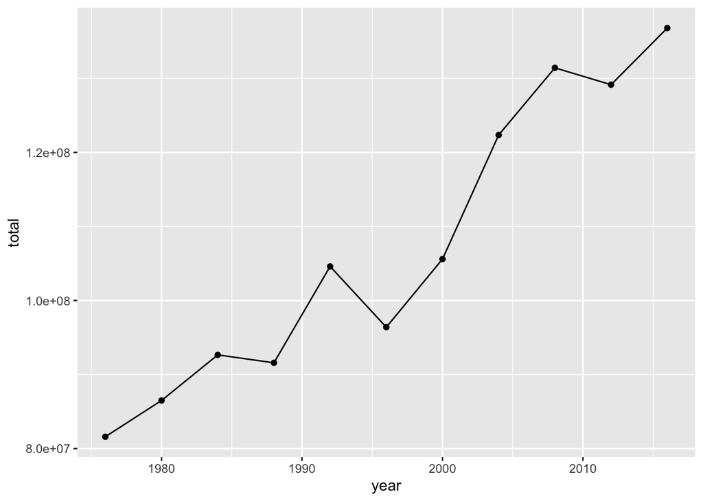

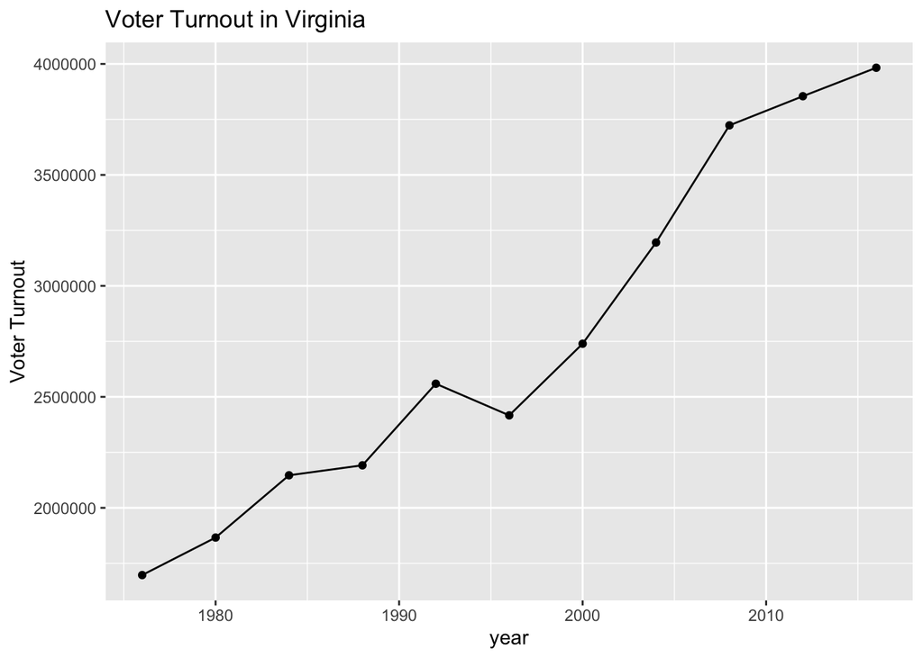

```r
#Voter turnout by State, could have user select state
presidential_turnout %>%
  filter(state == "Virginia") %>%
  ggplot(aes(year,totalvotes)) +
  ggtitle("Voter Turnout in Virginia") +
  ylab("Voter Turnout") +
  geom_line() +
  geom_point()
```

What we realized is that this only communicated the number of total people that voted from a given state. This would not be an effective way to show voter turnout especially when comparing a state like California with a high population to Oklahoma with a much lower population. This is why we pulled the voter turnout percentage from each state using the dataset provided by the United States Election Project, as talked about above.

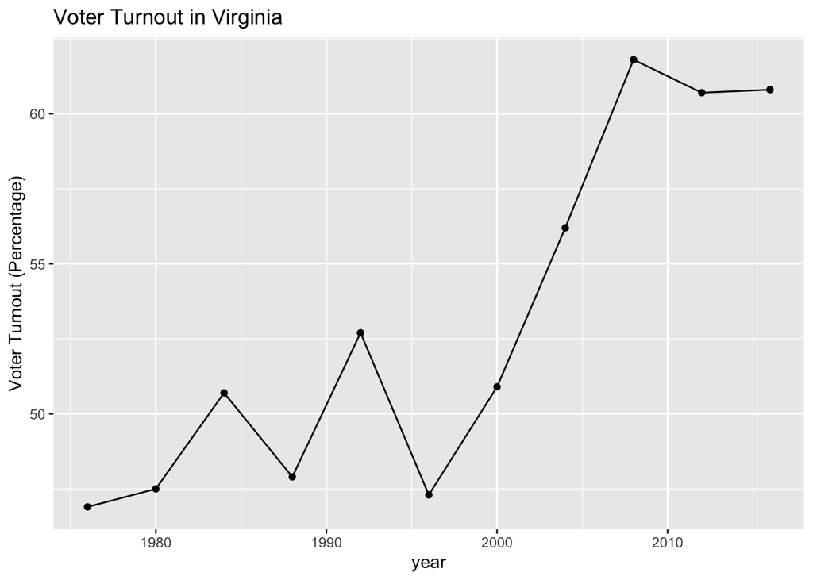

```r
# Use the turnout percentage
#Voter turnout by State, could have user select state
turnout <- read.csv("Data/Turnout.csv") %>%
  filter(X %in% seq(1976, 2016, by = 4)) %>%
  select(X, State, X.4) %>%
  rename(year=X,state=State, turnout=X.4)
turnout_1976 <- read.csv("Data/1976_Turnout.csv")
turnout_2016 <- read.csv("Data/2016_Turnout.csv") %>% mutate(State=recode(State,!!!c("Dist. of Columbia"="District of Columbia")))
presidential_turnout <- turnout_1976 %>%
  rename(year=Year,state=State,turnout=Turnout) %>% rbind(turnout) %>%
  rbind(turnout_2016 %>% rename(year=Year,state=State,turnout=Turnout)) %>%
  mutate(year = as.numeric(as.character(year)),turnout=as.numeric(str_replace(turnout,"%",""))) %>%
  filter(state !='United States')

presidential_turnout %>%
  filter(state == "Virginia") %>% # Show example for one state
  ggplot(aes(year,turnout)) +
  ggtitle("Voter Turnout in Virginia") +
  ylab("Voter Turnout (Percentage)") +
  geom_line() +
  geom_point()
```

We then looked at the margin of victory for each state. With this, we hoped to show how some states, such as Oklahoma and Wyoming were strongholds that had large margins of victory, whereas, other states such as New Hampshire were closer in margin. We also wanted to see what trends existed in these margins over time. What have the margins been like over time for a battleground state as compared to a stronghold state.

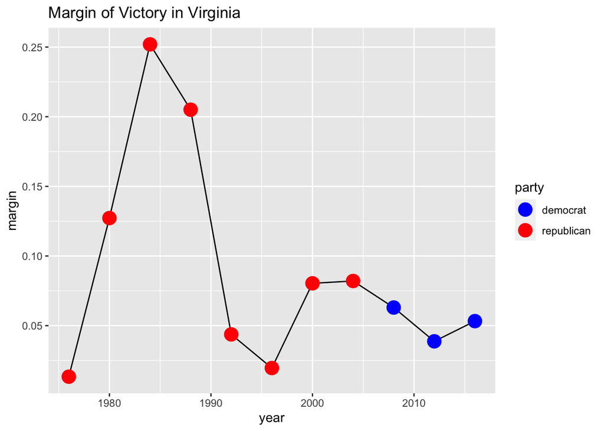

```r
# Margin of Victory, by state
margin_pres %>%
  filter(state %in% c("Virginia")) %>%
  ggplot(aes(year,margin)) +
  geom_line() +
  geom_point(aes(colour = party), size = 5) +
  ggtitle("Margin of Victory in Virginia") +
  scale_color_manual(values=c("blue", "red"))
```

What we realized was that we could use a heatmap to better communicate the overall trends in turnout, margins of victory, and the result of the election for each state. This was the method we used on our shiny application. Users would be able to pick the year of choice and whether they wanted to display the turnout, margin of victory, or result for each state.

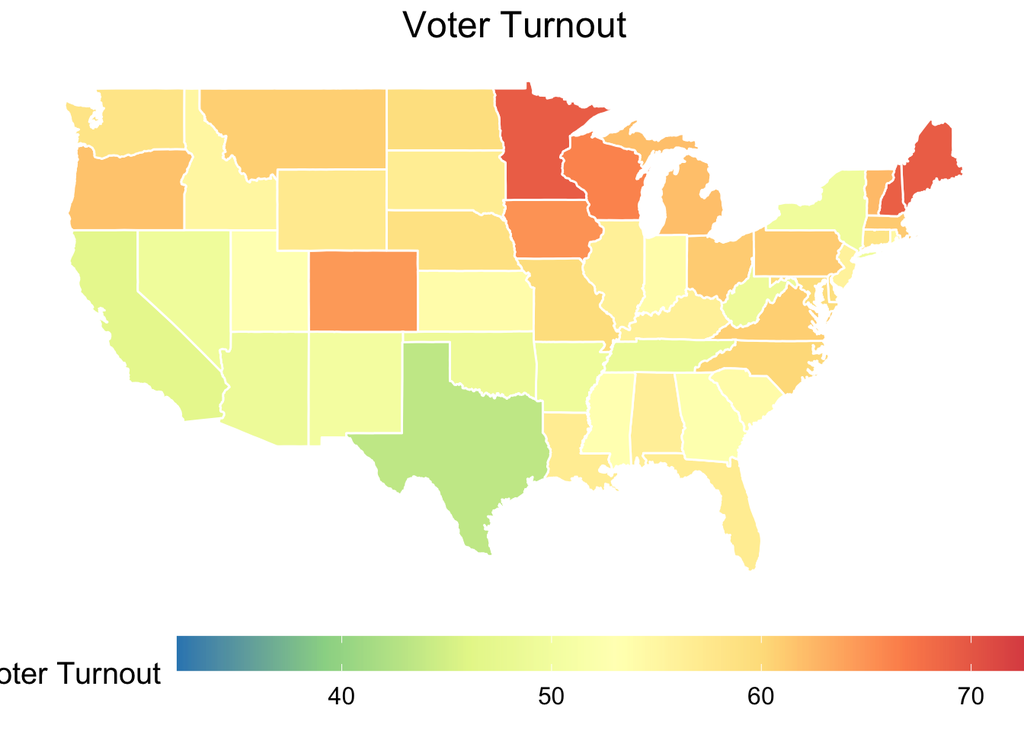

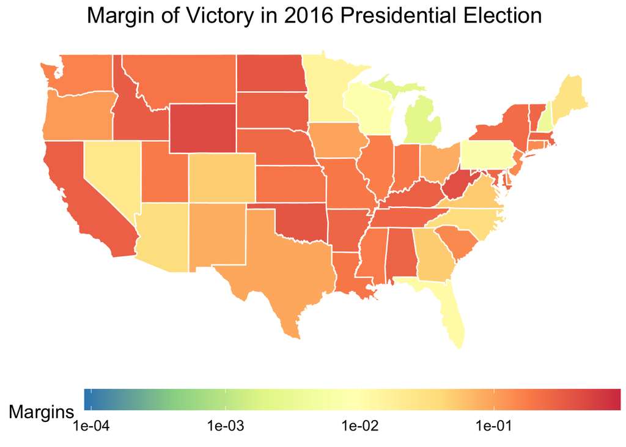

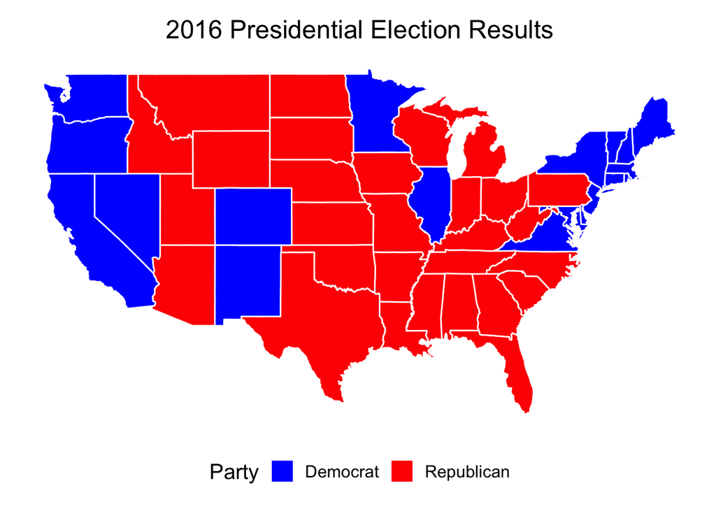

#### Chance of Influencing a Single Election

Andrew Gelman published multiple papers and articles, as detailed above, that used statistical models to find the chance a single vote would swing an election. This served as our main launching point for finding the value in a vote. By equating this probability to each person’s individual vote, we can start to answer how much value is in a vote. For instance, in the graph below we can see that a singular vote in Nevada (5 in 10 million) has a much higher chance of swinging an election as compared to Wyoming, which is almost 0 (1 in 30 billion). Thus the value of that singular vote in Nevada can be considered to be much higher than in Wyoming. We then extend this idea into our next section where we discuss the monetary value of a vote.

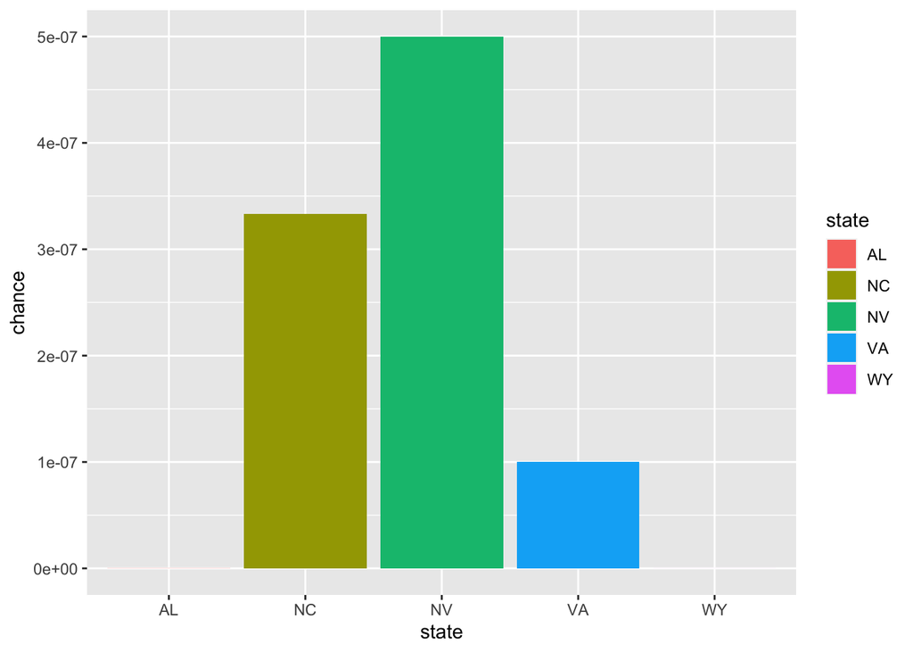

```r
# Chance of influencing the election, based on 2012 results
# Show 5-6 states
influence$chance <- as.numeric(influence$chance)
influence %>%
  filter(state %in% c("AL", "NV", "NC", "VA", "WY")) %>%
  ggplot(aes(state, chance, fill = state)) +
  geom_bar(stat="identity")
```

#### Discretionary Budget Breakdown

When understanding the value of a vote, we thought to first find out the money spent during a president’s term. This comes in the form of discretionary spending, which is allocated by a plan proposed by the president that is then approved. The reasoning behind this is so users could better understand where their vote was going. For instance, in 1976 presidency, the legislative branch received a total of $4,543,000,000, while the Judicial Branch only received $ 1,996,000,000 in comparison. From this, we can see the breakdown of how each president allocated their discretionary spending, and trends of this spending over time. Below is a table showing the discretionary spending for each agency from 1976 to an estimated amount during the 2020 presidency.

```r
head(budg_admin)
```

|  | 1976 | 1980 | 1984 | 1988 | 1992 | 1996 | 2000 | 2004 | 2008 | 2012 | 2016 | 2020 |
| --- | --- | --- | --- | --- | --- | --- | --- | --- | --- | --- | --- | --- |
| Legislative Branch | 4543 | 5868 | 6654 | 8382 | 9168 | 9723 | 13293 | 15521 | 18341 | 17270 | 19468 | 22607 |
| Judicial Branch | 1996 | 3072 | 4661 | 7051 | 10339 | 13265 | 17878 | 21876 | 25519 | 26170 | 28742 | 31220 |
| Department of Agriculture | 23852 | 30701 | 35513 | 48059 | 62847 | 64485 | 83238 | 96390 | 107095 | 98272 | 114046 | 98933 |
| Department of Commerce | 14428 | 7952 | 9093 | 12179 | 14873 | 22036 | 21955 | 27459 | 44264 | 33808 | 49474 | 31291 |
| Department of Defense--Military Programs | 488232 | 886277 | 1133483 | 1191238 | 1019100 | 1075773 | 1566666 | 2280331 | 2689392 | 2299657 | 2677099 | 2916912 |
| Department of Education | 43138 | 45409 | 59218 | 79929 | 94924 | 114517 | 198370 | 230678 | 355272 | 268265 | 283110 | 266239 |

From the graph below, we can see that Department of Education’s allocated budget increased much faster compared to the Department of Transportation’s. We can also see a sharp increase in the Department of Education in 2008, or President Obama’s first term.

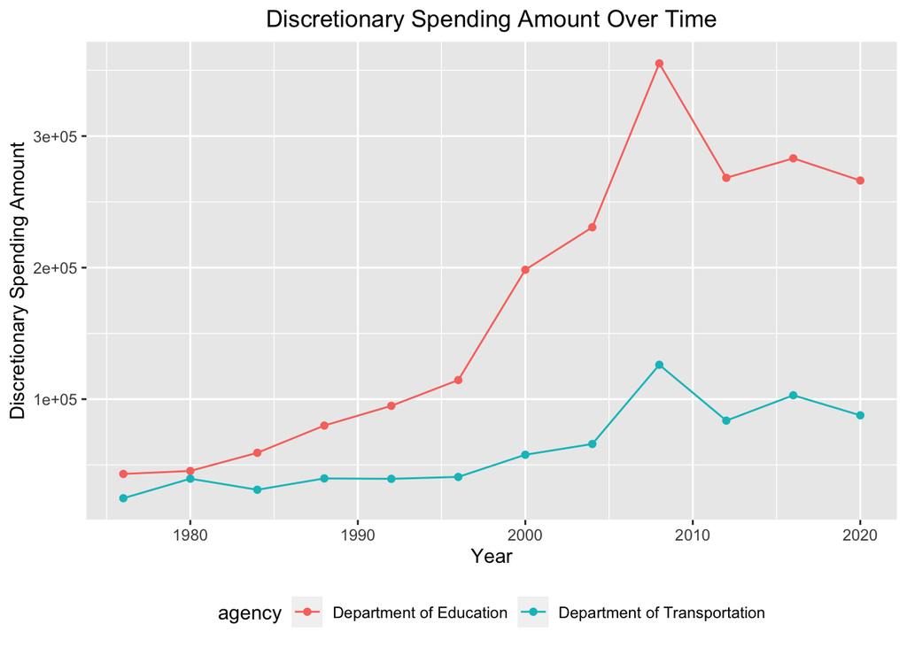

```r
# Show the discretionary spending for the given government agencies
gov_agencies <- c("Department of Education", "Department of Transportation")
line_data <- budg_admin %>%
  .[gov_agencies,] %>%
  tibble::rownames_to_column("agency") %>%
  gather(year,budget,-agency) %>%
  mutate(year = as.numeric(year))

line_data %>%
  ggplot(aes(x=as.numeric(year), y=budget, color=agency)) +
  geom_line() +
  geom_point() +
  xlab("Year") +
  ylab("Discretionary Spending Amount") +
  ggtitle('Discretionary Spending Amount Over Time') +
  theme(legend.position="bottom",
        # center title
        plot.title = element_text(hjust = 0.5))
```

#### Value of a Vote

We now move into the actual monetary value of a vote. Given the discretionary spending during a president’s term and the probability of a singular vote in a given state, the expected value of the vote is equal to:

$$E[Value] = Discretionary Spending * P(Vote|State)$$

First we filter by state and find the probability of one vote turning an election for that state:

| state | chance |
| --- | --- |
| VA | 1e-07 |

We can then plot this value for each presidency term from 1976 to 2016 for a given state and agency to find the expected value of a vote. As can be seen in the plot below, the expected value of a single vote in Virginia for the 2008 presidency was greater than $35,000 towards the Department of Education. This is an incredibly large amount a single vote holds and shows just how much power a single vote can contribute.

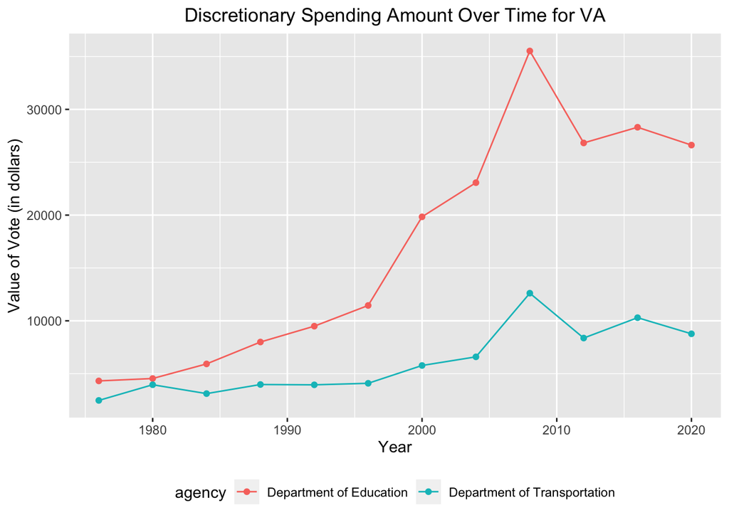

```r
# Show the value of a vote for the given agencies
line_data <- (influence %>% filter(state == chosen_state) %>%
      .$chance * budg_admin *1e6) %>%
      .[gov_agencies,] %>%
      tibble::rownames_to_column("agency") %>%
      gather(year,budget,-agency)


line_data %>%
  ggplot(aes(x=as.numeric(year), y=budget, color=agency)) +
  geom_line() +
  geom_point() +
  xlab("Year") +
  ylab("Value of Vote (in dollars)") +
  ggtitle(sprintf('Discretionary Spending Amount Over Time for %s',chosen_state)) +
  theme(legend.position="bottom",
        # center title
        plot.title = element_text(hjust = 0.5))
```

## ML Analysis - 2024 Competitive State prediction

We want to forecast which state will become a competitive state in the upcoming election. A state is defined to be competitive when the winning candidate only wins 1% or less of the total number of votes in that state. We start by visually assessing the relationship between vote margins and voter turnout each state using a bubble plot, where the size of the bubble is represented by the number of electoral votes that state have. We webscraped the number of electoral votes for each state historically since 1976 to 2016.

```r
### Relationship between  over Time
# Webcrape historical number of electoral votes by state by year
url <- "https://www.270towin.com/state-electoral-vote-history/"
electoral_votes <- read_html(url) %>% html_nodes("table") %>% html_table %>% .[[1]]
electoral_votes <- electoral_votes %>% gather(year,nvotes,-1)
names(electoral_votes) <- c('state','year','nvotes')
electoral_votes <- electoral_votes %>% mutate(year=as.numeric(year)) %>% filter(year %in% seq(1976,2016,4))
write.csv(electoral_votes,'Data/Electoral_Votes_by_State.csv',row.names=F)
```

Now we have all data necessary for our bubble chart:

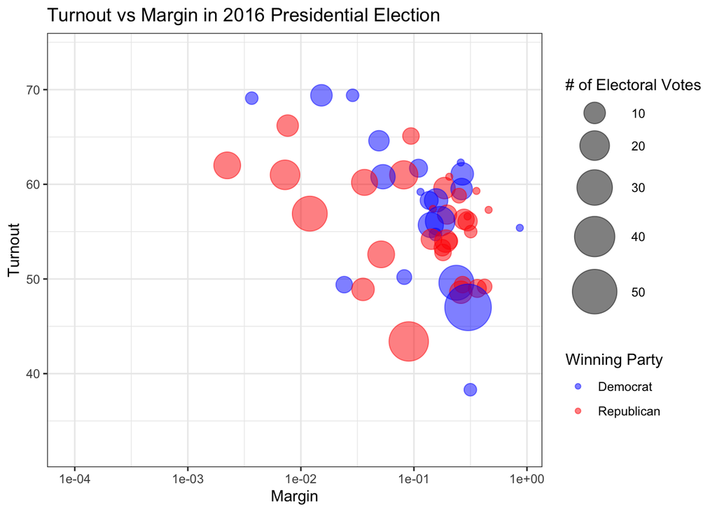

```r
### Relationship between  over Time
electoral_votes <- read.csv('Data/Electoral_Votes_by_State.csv')
pres_turnout_and_margin <- presidential_turnout %>%
  left_join(margin_pres,by=c('state','year')) %>%
  left_join(electoral_votes,by=c('state','year'))

year_scatter <- 2016
scatter_data<- pres_turnout_and_margin %>% filter(year==year_scatter) %>%
                           left_join(influence,by='state') %>%
                           mutate(party=str_to_title(party))

color_scale_min <- c('Margins'= min(margin_pres$margin),'Voter Turnout'=min(presidential_turnout$turnout))
color_scale_max <- c('Margins'= max(margin_pres$margin),'Voter Turnout'=max(presidential_turnout$turnout))


p <- scatter_data %>%
  ggplot(aes(margin, turnout, color = party, size=nvotes)) +
  geom_point(alpha = 0.5) +
  xlab("Margin") +
  ylab("Turnout") +
  scale_x_log10(limits=c(color_scale_min['Margins'],color_scale_max['Margins'])) +
  ylim(c(color_scale_min['Voter Turnout'],color_scale_max['Voter Turnout'])) +
  # Set x and y axis limits to keep the same for each year
  # Make the legend titles nicer
  scale_color_manual(name='Winning Party',values=c("Democrat"="blue","Republican"="red","Democratic-Farmer-Labor"="darkgreen")) +
  scale_size_continuous(name = "# of Electoral Votes",range=c(2,15)) +

  # Change the title of the plot for each year
  # Returns a character vector containing a formatted combination
  # of text and variable values
  ggtitle(sprintf("Turnout vs Margin in %d Presidential Election", year_scatter)) +
  theme_bw()

p
```

For 2016 presidential election, there is definite negative correlation between voters turnout and vote margin results for each state. We will now fit a logistic regression model with linear covariates on historical data for which states were competitive in past presidential elections. The covariates in our regression include US Census variables for these states as well as the election year and voters turnout data for these states. We use election data starting from 2000, as we did not believe that data before this point was representative of possible swing states.

```r
# Put in Census variables as features
# Put in vote margins
state_name_to_abb <- setNames(state.name,state.abb)
full_set <- margin_pres %>%
  left_join(presidential_turnout,by=c('year','state')) %>%
  mutate(state=recode(state,!!!state_name_to_abb)) %>%
  left_join(demo,by='state')
# make swing state
full_set <- full_set %>% mutate(swing_state = margin<= .01)
#plan A predict swing state in 2024
#swing state: vote_margin < .0001
# predictors: census variables, year (numeric), electoral votes
set_in <- full_set %>%
  filter(year >= 2000) %>%
  select(-margin, - party, - white_pct) %>% unique()
swing_clf<- glm(swing_state ~ . - swing_state- state,family=binomial(),data=set_in)
summary(swing_clf)
```

```
##
## Call:
## glm(formula = swing_state ~ . - swing_state - state, family = binomial(),
##     data = set_in)
##
## Deviance Residuals:
##      Min        1Q    Median        3Q       Max
## -1.13748  -0.29151  -0.09449  -0.01947   2.75975
##
## Coefficients:
##                          Estimate Std. Error z value Pr(>|z|)
## (Intercept)             1.847e+02  1.356e+02   1.363    0.173
## year                   -6.932e-02  6.081e-02  -1.140    0.254
## turnout                 9.565e-02  8.132e-02   1.176    0.240
## black_pct               1.698e-01  2.814e-01   0.603    0.546
## hispanic_pct            9.485e-02  4.130e-01   0.230    0.818
## nonwhite_pct           -1.394e-01  3.254e-01  -0.428    0.668
## foreignborn_pct        -1.107e+00  8.247e-01  -1.342    0.180
## female_pct             -5.310e-01  9.585e-01  -0.554    0.580
## age29andunder_pct      -1.070e+00  8.853e-01  -1.208    0.227
## age65andolder_pct       8.304e-01  9.322e-01   0.891    0.373
## median_hh_inc           4.323e-05  2.379e-04   0.182    0.856
## clf_unemploy_pct       -5.113e-01  5.723e-01  -0.893    0.372
## lesshs_pct              1.533e+00  1.378e+00   1.112    0.266
## lesscollege_pct         8.324e-02  2.295e+00   0.036    0.971
## lesshs_whites_pct      -1.766e+00  1.321e+00  -1.336    0.181
## lesscollege_whites_pct  8.420e-02  2.169e+00   0.039    0.969
## rural_pct              -1.268e-01  1.435e-01  -0.883    0.377
## ruralurban_cc          -9.396e-01  1.447e+00  -0.649    0.516
##
## (Dispersion parameter for binomial family taken to be 1)
##
##     Null deviance: 106.124  on 234  degrees of freedom
## Residual deviance:  70.287  on 217  degrees of freedom
##   (20 observations deleted due to missingness)
## AIC: 106.29
##
## Number of Fisher Scoring iterations: 12
```

```r
roc.1 <- roc(drop_na(set_in)$swing_state, fitted(swing_clf))
```

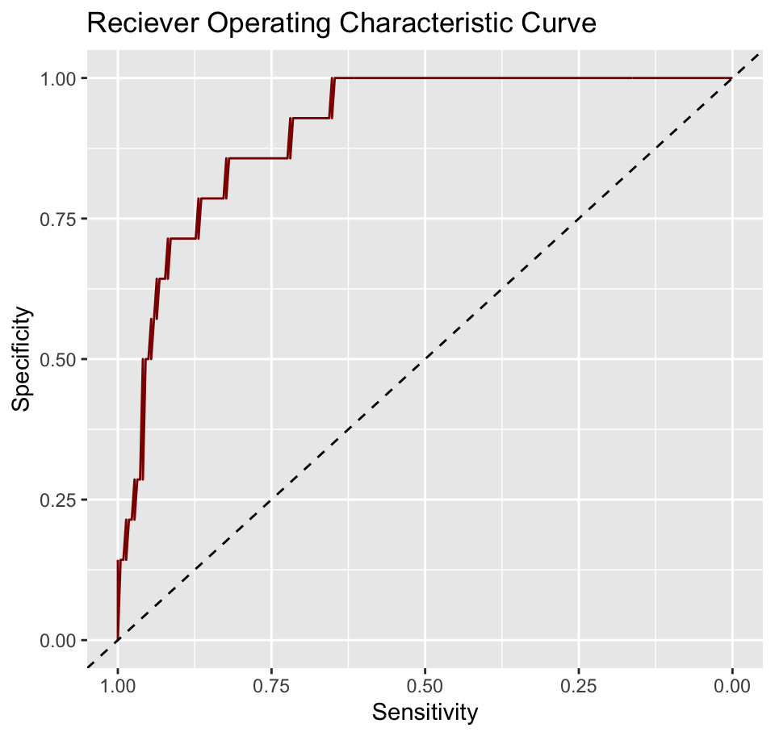

```r
roc_df <- as.data.frame(cbind(roc.1$sensitivities,roc.1$specificities))
names(roc_df) <- c('sensitivity','specificity')
roc_df <- roc_df %>% arrange(desc(sensitivity),desc(specificity))
roc_df %>%
  ggplot(aes(specificity,sensitivity)) +
  geom_line(color='darkred') +
  geom_abline(aes(slope=1,intercept=1),linetype='dashed') +
  xlim(1,0) +
  ggtitle("Reciever Operating Characteristic Curve") +
  xlab("Sensitivity") +
  ylab("Specificity")
```

```r
print(auc(roc.1))
```

```
## Area under the curve: 0.9072
```

We achieve 0.9 for the AUC of our ROC Curve, which means our classifier fitted pretty well onto the dataset. The US Census variables were not as helpful and neither was the year. Now we can forecast into 2024 on which state will be competitive.

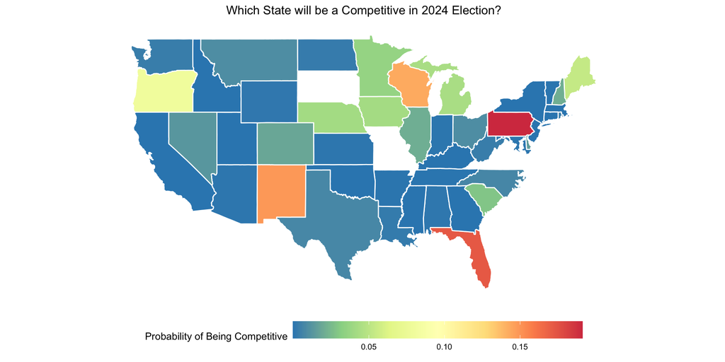

```r
# use latest turnout
predict_inputs <- set_in %>%
  filter(year==2016) %>%
  unique() %>%
  ungroup() %>%
  select(-year) %>%
  add_column(year=2024) %>%
  drop_na()

predictions_2024 <- predict(swing_clf, newdata = predict_inputs, type="response")
names(predictions_2024) <- predict_inputs$state
predictions_2024 <- as.data.frame(predictions_2024) %>% tibble::rownames_to_column('state') %>% rename(swing_prob=predictions_2024)

write.csv(predictions_2024,'Data/2024_swing_state_predictions.csv')
```

## Final Analysis

The goal of this project was to understand more about the landscape of voting and how much it impacts us. Our initial exlporatory analysis allowed us to understand more about the nuances within each presidenital election like voter turnout, margins of victory, demographics, and results of each election over the last 40 years. This gave us, and hopefully the user, how elections have changed over time and where they are trending.

We then moved onto the value of a single vote. This started with understanding the probability of a single vote overturning an election. We showed this through Andrew Gelman’s probability table that gave such a probability for each state. This was then coupled with the discretionary budget throughout a president’s term to find the value in a single vote. We hoped to communicate that voting can be viewed as more than just a civic duty, and how much impact it had in our lives. By illustrating that a single vote in Virginia resulted in expected value of $35,000 just for one agency, we start to understand just how much value and power comes with a vote. We also encouraged users to find out more about the value of a vote and trends in voting with our Shiny app.